# Biostat 203B Homework 4 (Draft)

Due Mar 19 @ 11:59PM

Load database libraries and the tidyverse frontend:

```r
library(dplyr)
library(tidyverse)
library(lubridate)
library(miceRanger)
library(MatrixModels)
library(data.table)
library(rstatix)
library(glmnet)
library(randomForest)
library(caret)
library(Matrix)
```

## Q1. Missing data

Through the Shiny app developed in HW3, we observe abundant missing values in the MIMIC-IV ICU cohort we created. In this question, we use multiple imputation to obtain a data set without missing values.

0. Read following tutorials on the R package miceRanger for imputation: https://github.com/farrellday/miceRanger, https://cran.r-project.org/web/packages/miceRanger/vignettes/miceAlgorithm.html.

A more thorough book treatment of the practical imputation strategies is the book [*Flexible Imputation of Missing Data*](https://stefvanbuuren.name/fimd/) by Stef van Buuren.

1. Explain the jargon MCAR, MAR, and MNAR.

**Solution**: MCAR: this is missing completely at random. The missing data values do not relate to any other data in the dataset and there is no pattern to the missing data values. MAR: Missing at random - Missing data do have a relationship with the other variables in the dataset.The missing values themselves are random though. MNAR: missing not at random, not only are the pattern of missing values is related to others in the dataset, the missing values are also not random as well.

2. Explain in a couple of sentences how the Multiple Imputation by Chained Equations (MICE) work. **Solution**: This replaces missing values by making certain assumptions about the missing values. Makes the assumptions based on MCAR, MAR etc. until it converges and it will create however many datasets you choose. Then you can analyize however is needed.
3. Perform a data quality check of the ICU stays data. Discard variables with substantial missingness, say >5000 `NA`s. Replace apparent data entry errors by `NA`s.

```r
icu_coh <-readRDS(str_c("/home/asburysean/biostat-203b-2021-winter/"
                        ,"Hw3/mimiciv_shiny/icu_cohort.rds"))
na_count <-sapply(icu_coh, function(y) sum(length(which(is.na(y)))))
na_count <- data.frame(na_count)
na_count
```

```
##                                      na_count
## subject_id                                  0
## hadm_id                                     0
## stay_id                                     0
## first_careunit                              0
## last_careunit                               0
## intime                                      0
## outtime                                     0
## los                                         0
## admittime                                   0
## dischtime                                   0
## deathtime                               44872
## admission_type                              0
## admission_location                          0
## discharge_location                        452
## insurance                                   0
## language                                    0
## marital_status                           4176
## ethnicity                                   0
## edregtime                               18462
## edouttime                               18462
## hospital_expire_flag                        0
## gender                                      0
## anchor_age                                  0
## anchor_year                                 0
## anchor_year_group                           0
## dod                                     50048
## bicarbonate                               861
## calcium                                  2374
## chloride                                  835
## creatinine                                839
## glucose                                   850
## magnesium                                1017
## potassium                                 852
## sodium                                    826
## hematocrit                               1016
## wbc                                      1032
## lactate                                 19843
## age_adm                                     0
## heart_rate                                  8
## non_invasive_blood_pressure_systolic      572
## non_invasive_blood_pressure_mean          593
## respiratory_rate                           34
## temperature_fahrenheit                    827
## arterial_blood_pressure_systolic        29019
## arterial_blood_pressure_mean            28897
## days_death                              44872
## died_30days                                 0
```

```r
# Normally wouldnt drop all these but need space in order for it to run
drops <- c("first_careunit","last_careunit", "intime", "outtime", "los",
           "admittime", "dischtime", "deathtime", "admission_type",
           "admission_location", "discharge_location", "insurance", "language",
           "days_death", "arterial_blood_pressure_mean",
           "arterial_blood_pressure_systolic", "lactate", "dod",
           "anchor_year_group", "anchor_year", "anchor_age",
           "hospital_expire_flag", "edouttime", "edregtime", "hadm_id",
           "stay_id")
icu_coh_tble <- icu_coh[ , !(names(icu_coh) %in% drops)]
print(icu_coh_tble)
```

```
## # A tibble: 50,048 x 21
##    subject_id marital_status ethnicity gender bicarbonate calcium chloride
##         <int> <chr>          <chr>     <chr>        <dbl>   <dbl>    <dbl>
##  1   10000980 MARRIED        BLACK/AF… F               23     9.2      103
##  2   10004733 SINGLE         UNKNOWN   M               24     9.5      109
##  3   10006821 MARRIED        WHITE     F               19     8        107
##  4   10009628 MARRIED        HISPANIC… M               23     7.5      109
##  5   10012261 MARRIED        BLACK/AF… M               26     9.7      103
##  6   10012552 MARRIED        UNKNOWN   M               23     8.4      113
##  7   10013419 SINGLE         WHITE     M               26     7.7      107
##  8   10014610 MARRIED        BLACK/AF… M               19     8.2      108
##  9   10016742 SINGLE         BLACK/AF… F               33    10        103
## 10   10017308 MARRIED        WHITE     F               21     9        106
## # … with 50,038 more rows, and 14 more variables: creatinine <dbl>,
## #   glucose <dbl>, magnesium <dbl>, potassium <dbl>, sodium <dbl>,
## #   hematocrit <dbl>, wbc <dbl>, age_adm <dbl>, heart_rate <dbl>,
## #   non_invasive_blood_pressure_systolic <dbl>,
## #   non_invasive_blood_pressure_mean <dbl>, respiratory_rate <dbl>,
## #   temperature_fahrenheit <dbl>, died_30days <dbl>
```

```r
colnames(icu_coh_tble)
```

```
##  [1] "subject_id"
##  [2] "marital_status"
##  [3] "ethnicity"
##  [4] "gender"
##  [5] "bicarbonate"
##  [6] "calcium"
##  [7] "chloride"
##  [8] "creatinine"
##  [9] "glucose"
## [10] "magnesium"
## [11] "potassium"
## [12] "sodium"
## [13] "hematocrit"
## [14] "wbc"
## [15] "age_adm"
## [16] "heart_rate"
## [17] "non_invasive_blood_pressure_systolic"
## [18] "non_invasive_blood_pressure_mean"
## [19] "respiratory_rate"
## [20] "temperature_fahrenheit"
## [21] "died_30days"
```

```r
icu_coh_tble$bicarbonate <- replace(icu_coh_tble$bicarbonate,
                            is_extreme(icu_coh_tble$bicarbonate) == TRUE, NA)
icu_coh_tble$calcium <- replace(icu_coh_tble$calcium,
                            is_extreme(icu_coh_tble$calcium) == TRUE, NA)
icu_coh_tble$chloride <- replace(icu_coh_tble$chloride,
                            is_extreme(icu_coh_tble$chloride) == TRUE, NA)
icu_coh_tble$creatinine <- replace(icu_coh_tble$creatinine,
                            is_extreme(icu_coh_tble$creatinine) == TRUE, NA)
icu_coh_tble$glucose <- replace(icu_coh_tble$glucose,
                            is_extreme(icu_coh_tble$glucose) == TRUE, NA)
icu_coh_tble$magnesium <- replace(icu_coh_tble$magnesium,
                            is_extreme(icu_coh_tble$magnesium) == TRUE, NA)
icu_coh_tble$potassium <- replace(icu_coh_tble$potassium,
                            is_extreme(icu_coh_tble$potassium) == TRUE, NA)
icu_coh_tble$sodium <- replace(icu_coh_tble$sodium,
                            is_extreme(icu_coh_tble$sodium) == TRUE, NA)
icu_coh_tble$hematocrit <- replace(icu_coh_tble$hematocrit,
                            is_extreme(icu_coh_tble$hematocrit) == TRUE, NA)
icu_coh_tble$wbc <- replace(icu_coh_tble$wbc,
                            is_extreme(icu_coh_tble$wbc) == TRUE, NA)
icu_coh_tble$heart_rate <- replace(icu_coh_tble$heart_rate,
                            is_extreme(icu_coh_tble$heart_rate) == TRUE, NA)
icu_coh_tble$non_invasive_blood_pressure_systolic <-
  replace(icu_coh_tble$non_invasive_blood_pressure_systolic,
                            is_extreme(
                              icu_coh_tble$non_invasive_blood_pressure_systolic)
                           == TRUE, NA)
icu_coh_tble$non_invasive_blood_pressure_mean <- replace(icu_coh_tble$non_invasive_blood_pressure_mean,
                            is_extreme(
                              icu_coh_tble$non_invasive_blood_pressure_mean)
                            == TRUE, NA)
icu_coh_tble$respiratory_rate <- replace(icu_coh_tble$respiratory_rate,
                            is_extreme(icu_coh_tble$respiratory_rate)
                            == TRUE, NA)
icu_coh_tble$temperature_fahrenheit <- replace(
  icu_coh_tble$temperature_fahrenheit,
  is_extreme(icu_coh_tble$temperature_fahrenheit) == TRUE, NA)
#Checking for unusual values
table(icu_coh_tble$marital_status)
```

```
##
## DIVORCED  MARRIED   SINGLE  WIDOWED
##     3493    22745    13438     6196
```

```r
table(icu_coh_tble$ethnicity)
```

```
##
## AMERICAN INDIAN/ALASKA NATIVE                         ASIAN
##                            87                          1447
##        BLACK/AFRICAN AMERICAN               HISPANIC/LATINO
##                          4575                          1739
##                         OTHER              UNABLE TO OBTAIN
##                          2380                           758
##                       UNKNOWN                         WHITE
##                          5337                         33725
```

```r
table(icu_coh_tble$gender)
```

```
##
##     F     M
## 22032 28016
```

```r
table(icu_coh_tble$age_adm)
```

```
##
##   18   19   20   21   22   23   24   25   26   27   28   29   30   31   32   33
##   77  116  218  196  219  233  195  218  239  206  240  249  220  224  258  249
##   34   35   36   37   38   39   40   41   42   43   44   45   46   47   48   49
##  272  272  267  272  294  274  289  307  349  359  389  420  491  510  542  565
##   50   51   52   53   54   55   56   57   58   59   60   61   62   63   64   65
##  659  666  798  813  848  877  936  876  910  990 1069 1080 1073 1102 1155 1115
##   66   67   68   69   70   71   72   73   74   75   76   77   78   79   80   81
## 1153 1220 1162 1144 1127 1068 1023 1059 1016 1042  985 1034  981  968  975  955
##   82   83   84   85   86   87   88   89   90   91   92   93   94   95   96   97
##  995  892  904  838  770  740  655  505  186 1820  264  145   94   54   27   30
##   98   99  100  102
##   12    5    3    1
```

```r
table(icu_coh_tble$died_30days)
```

```
##
##     0     1
## 45159  4889
```

4. Impute missing values by `miceRanger` (request $m=3$ datasets). This step is very computational intensive. Make sure to save the imputation results as a file.

```r
# I had to use max.depth=10 due to computing power and it couldnt converge
seqTime <- system.time(
  miceObj <- miceRanger(
    icu_coh_tble
    , m=3
    , max.depth=10
    , returnModels = TRUE
    , verbose=FALSE
  )
)
miceObj
```

```
## Class:          miceDefs
## Datasets:       3
## Iterations:     5
## Total Seconds:  10752
## Imputed Cols:   16
## Estimated Time per Additional Iteration is 2150 Seconds
## Estimated Time per Additional Dataset is 3584 Seconds
##
## For additional metrics, see the different plotting functions.
```

```r
icucoh_new <- completeData(miceObj)
icucoh_new
```

```
## $Dataset_1
##        subject_id marital_status              ethnicity gender bicarbonate
##     1:   10000980        MARRIED BLACK/AFRICAN AMERICAN      F          23
##     2:   10004733         SINGLE                UNKNOWN      M          24
##     3:   10006821        MARRIED                  WHITE      F          19
##     4:   10009628        MARRIED        HISPANIC/LATINO      M          23
##     5:   10012261        MARRIED BLACK/AFRICAN AMERICAN      M          26
##    ---
## 50044:   19995091        MARRIED                  WHITE      M          21
## 50045:   19998770         SINGLE                  WHITE      F          26
## 50046:   19999068       DIVORCED                  WHITE      M          21
## 50047:   19999625        MARRIED                  WHITE      M          19
## 50048:   19614937        WIDOWED                  WHITE      F          23
##        calcium chloride creatinine glucose magnesium potassium sodium
##     1:     9.2      103        2.2     144       2.0       4.2    139
```

[output cut: 170 more lines]

5. Make imputation diagnostic plots and explain what they mean.

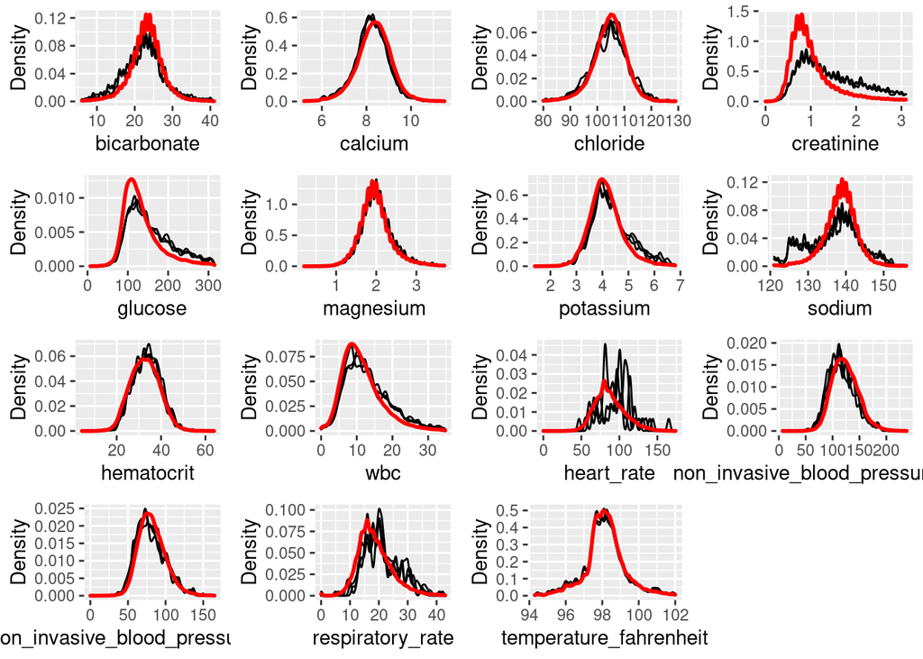

```r
# The red line is the density of the original nonmissing data and the black line is the density of the imputed data sets. You can see that there are some differences but and that could tell us if its MCAR. We had to use max.depth=10 so that could cause some issues.
plotDistributions(miceObj,vars='allNumeric')
```

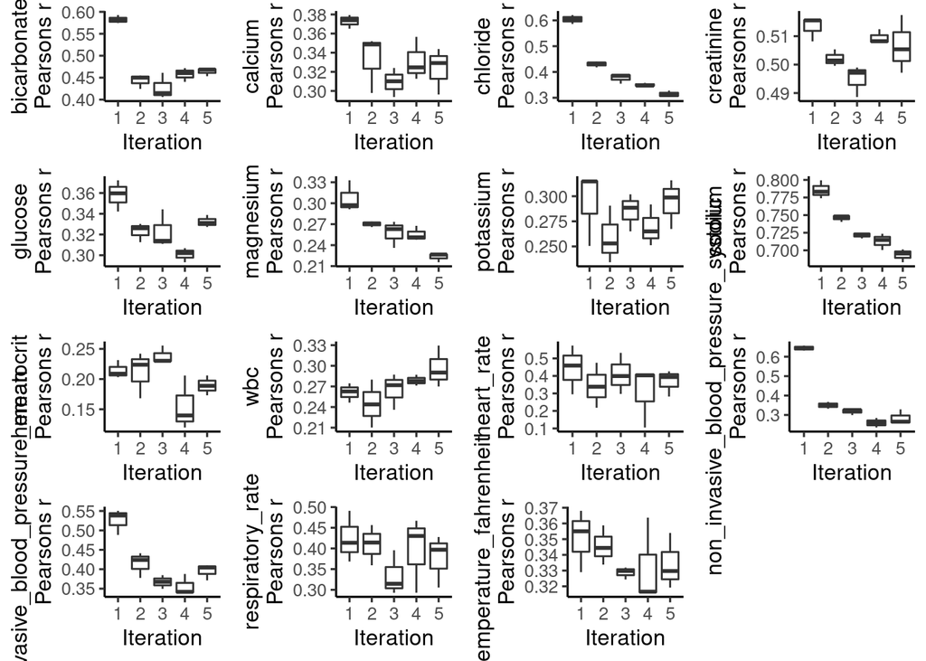

```r
# boxplot of the correlations between imputed values for each iteration and every combo. As you can see we have convergence issues due to computational power.
plotCorrelations(miceObj,vars='allNumeric')
```

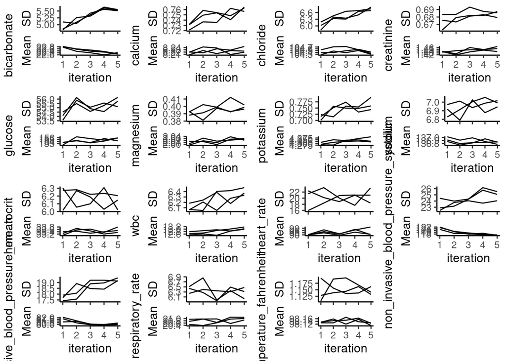

```r
# This shows if we have convergence issues and as you can see that we do have some due to computational power issues but noramally we would do more imputations if needed.
plotVarConvergence(miceObj,vars='allNumeric')
```

6. Obtain a complete data set by averaging the 3 imputed data sets.

```r
df1 <- icucoh_new$Dataset_1
df2 <- icucoh_new$Dataset_2
df3 <- icucoh_new$Dataset_3

#This works on my local but for some reason wasnt working on the server
# dfa <- data.frame(data.matrix(df1))
# dfb <- as.data.frame(data.matrix(df2, rownames.force = NA))
# dfc <- as.data.frame(data.matrix(df3, rownames.force = NA))
df1$ethnicity <- as.numeric(factor(df1$ethnicity))
df1$marital_status <- as.numeric((factor(df1$marital_status)))
df1$gender <- as.numeric(factor(df1$gender))
df2$ethnicity <- as.numeric(factor(df2$ethnicity))
df2$marital_status <- as.numeric((factor(df2$marital_status)))
df2$gender <- as.numeric(factor(df2$gender))
df3$ethnicity <- as.numeric(factor(df3$ethnicity))
df3$marital_status <- as.numeric((factor(df3$marital_status)))
df3$gender <- as.numeric(factor(df3$gender))
head(df3)
```

```
##    subject_id marital_status ethnicity gender bicarbonate calcium chloride
## 1:   10000980              2         3      1          23     9.2      103
## 2:   10004733              3         7      2          24     9.5      109
## 3:   10006821              2         8      1          19     8.0      107
## 4:   10009628              2         4      2          23     7.5      109
## 5:   10012261              2         3      2          26     9.7      103
## 6:   10012552              2         7      2          23     8.4      113
##    creatinine glucose magnesium potassium sodium hematocrit  wbc age_adm
## 1:        2.2     144       2.0       4.2    139       30.8  5.4      76
## 2:        0.6      86       2.2       3.7    146       30.9  7.4      51
## 3:        0.8      89       1.7       3.6    142       26.4 20.7      61
## 4:        0.7     124       1.9       3.8    139       21.2  9.2      58
## 5:        1.0     204       2.3       4.5    140       36.6  6.7      70
## 6:        1.0     115       2.2       3.4    142       25.9  5.3      78
##    heart_rate non_invasive_blood_pressure_systolic
```

[output cut: 20 more lines]

```r
#Avg and bind, couldnt factorize marriage variable after avg since there were some decimals for some weird reason so kept it as continuous.
avgicu_coh <- rbindlist(list(df1, df2,df3))[,lapply(.SD,mean), list(subject_id)]
head(avgicu_coh)
```

```
##    subject_id marital_status ethnicity gender bicarbonate calcium chloride
## 1:   10000980              2         3      1          23     9.2      103
## 2:   10004733              3         7      2          24     9.5      109
## 3:   10006821              2         8      1          19     8.0      107
## 4:   10009628              2         4      2          23     7.5      109
## 5:   10012261              2         3      2          26     9.7      103
## 6:   10012552              2         7      2          23     8.4      113
##    creatinine glucose magnesium potassium sodium hematocrit  wbc age_adm
## 1:  2.2000000     144       2.0       4.2    139       30.8  5.4      76
## 2:  0.8666667      86       2.2       3.7    146       30.9  7.4      51
## 3:  0.8000000      89       1.7       3.6    142       26.4 20.7      61
## 4:  0.7000000     124       1.9       3.8    139       21.2  9.2      58
## 5:  1.0000000     204       2.3       4.5    140       36.6  6.7      70
## 6:  1.0000000     115       2.2       3.4    142       25.9  5.3      78
##    heart_rate non_invasive_blood_pressure_systolic
```

[output cut: 20 more lines]

```r
avgicu_coh$ethnicity <- as.factor(avgicu_coh$ethnicity)
avgicu_coh$gender <- as.factor(avgicu_coh$gender)
avgicu_coh$died_30days <- as.factor(avgicu_coh$died_30days)
```

## Q2. Predicting 30-day mortality

Develop at least two analytic approaches for predicting the 30-day mortality of patients admitted to ICU using demographic information (gender, age, marital status, ethnicity), first lab measurements during ICU stay, and first vital measurements during ICU stay. For example, you can use (1) logistic regression (`glm()` function), (2) logistic regression with lasso penalty (glmnet package), (3) random forest (randomForest package), or (4) neural network.

1. Partition data into 80% training set and 20% test set. Stratify partitioning according the 30-day mortality status.

```r
trainIndex <- createDataPartition(avgicu_coh$died_30days, p = .8, list = FALSE, times = 1)
head(trainIndex)
```

```
##      Resample1
## [1,]         2
## [2,]         3
## [3,]         4
## [4,]         5
## [5,]         6
## [6,]         7
```

```r
icuTrain <- avgicu_coh[ trainIndex,]
icuTest  <- avgicu_coh[-trainIndex,]
```

2. Train the models using the training set.

```r
#RandomForest
rf <- randomForest(
   died_30days~ .,
  data=icuTrain
)
rf
```

```
##
## Call:
##  randomForest(formula = died_30days ~ ., data = icuTrain)
##                Type of random forest: classification
##                      Number of trees: 500
## No. of variables tried at each split: 4
##
##         OOB estimate of  error rate: 9.27%
## Confusion matrix:
##       0   1 class.error
## 0 35959 169 0.004677812
## 1  3542 370 0.905419223
```

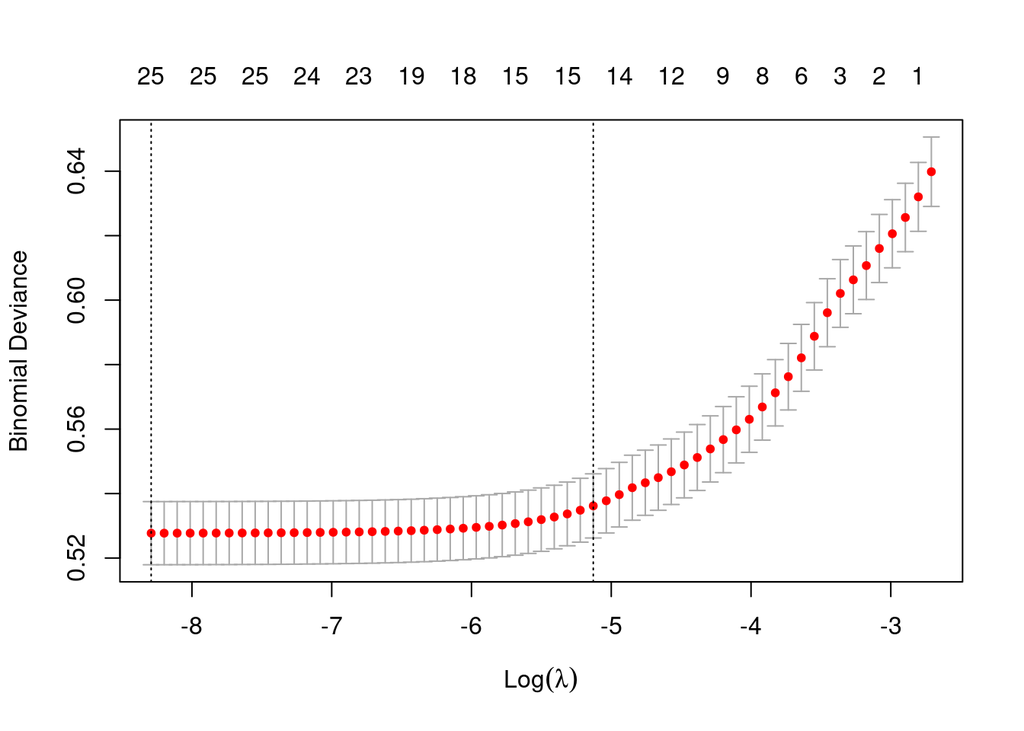

```r
#logistic regression
# Dumy code categorical predictor variables
x <- model.matrix(died_30days~., icuTrain)[,-1]
# Convert the outcome (class) to a numerical variable
y <- icuTrain$died_30days
set.seed(123)
cv.lasso <- cv.glmnet(x, y, alpha = 1, family = "binomial")
plot(cv.lasso)
```

```r
cv.lasso$lambda.min
```

```
## [1] 0.0002505553
```

```r
cv.lasso$lambda.1se
```

```
## [1] 0.005924355
```

```r
coef(cv.lasso, cv.lasso$lambda.min)
```

```
## 27 x 1 sparse Matrix of class "dgCMatrix"
##                                                  1
## (Intercept)                           6.780826e+00
## subject_id                            4.713640e-09
## marital_status                        1.252033e-02
## ethnicity2                            1.790749e-01
## ethnicity3                           -8.442777e-02
## ethnicity4                           -3.505338e-02
## ethnicity5                            1.110000e-01
## ethnicity6                            9.212315e-01
## ethnicity7                            8.587247e-01
## ethnicity8                            .
## gender2                              -1.455754e-01
## bicarbonate                          -9.915412e-02
## calcium                              -2.636297e-01
## chloride                             -9.022027e-02
## creatinine                            5.894397e-01
## glucose                               3.214172e-03
## magnesium                             7.334993e-02
## potassium                             5.259324e-02
## sodium                                9.138058e-02
## hematocrit                            1.569627e-03
## wbc                                   3.168654e-02
## age_adm                               2.884613e-02
## heart_rate                            9.120566e-03
## non_invasive_blood_pressure_systolic -7.110585e-03
## non_invasive_blood_pressure_mean      2.089208e-03
## respiratory_rate                      3.681195e-02
## temperature_fahrenheit               -1.304132e-01
```

```r
lasso.model <- glmnet(x, y, alpha = 1, family = "binomial",
                      lambda = cv.lasso$lambda.min)
# Make prediction on test data
x.test <- model.matrix(died_30days ~., icuTest)[,-1]
probabilities <- lasso.model %>% predict(newx = x.test)
predicted.classes <- ifelse(probabilities > 0.5, 1, 0)

# Model accuracy
observed.classes <- icuTest$died_30days
mean(predicted.classes == observed.classes)
```

```
## [1] 0.9044764
```

3. Compare model prediction performance on the test set.

```r
#Model accuracy RandomForest
pred = predict(rf, newdata=icuTest[])
confusionMatrix(pred, icuTest$died_30days)
```

```
## Confusion Matrix and Statistics
##
##           Reference
## Prediction    0    1
##          0 8989  903
##          1   42   74
##
##                Accuracy : 0.9056
##                  95% CI : (0.8997, 0.9112)
##     No Information Rate : 0.9024
##     P-Value [Acc > NIR] : 0.1442
##
##                   Kappa : 0.1171
##
##  Mcnemar's Test P-Value : <2e-16
##
##             Sensitivity : 0.99535
##             Specificity : 0.07574
##          Pos Pred Value : 0.90871
##          Neg Pred Value : 0.63793
##              Prevalence : 0.90238
##          Detection Rate : 0.89818
##    Detection Prevalence : 0.98841
##       Balanced Accuracy : 0.53555
##
##        'Positive' Class : 0
##
```